# Test+a+Perceptual+Phenomenon+zh

### 统计学：检验心理学现象

在下方单元格中回答问题并执行相关代码，你可以 参考项目指导 并在正式提交前查看 [项目要求](https://review.udacity.com/#!/rubrics/305/view)。提交时请将 Jupyter notebook 导出成 HTML 或者 PDF 进行提交（File -> Download As）。

背景信息

在一个Stroop （斯特鲁普）任务中，参与者得到了一列文字，每个文字都用一种油墨颜色展示。参与者的任务是将文字的打印颜色大声说出来。这项任务有两个条件：一致文字条件，和不一致文字条件。在一致文字条件中，显示的文字是与它们的打印颜色匹配的颜色词，如“红色”、“蓝色”。在不一致文字条件中，显示的文字是与它们的打印颜色不匹配的颜色词，如“紫色”、“橙色”。在每个情况中，我们将计量说出同等大小的列表中的墨色名称的时间。每位参与者必须全部完成并记录每种条件下使用的时间。

调查问题

作为一般说明，请确保记录你在创建项目时使用或参考的任何资源。作为项目提交的一部分，你将需要报告信息来源。

(1) 我们的自变量是什么？因变量是什么？

```python
#巧合雷同，不代表抄袭#
```

自变量：颜色词和墨色颜色是否一致 因变量：参与者说出的正确墨色颜色所用的时间

(2) 此任务的适当假设集是什么？你需要以文字和数学符号方式对假设集中的零假设和对立假设加以说明，并对数学符号进行定义。你想执行什么类型的统计检验？为你的选择提供正当理由（比如，为何该实验满足你所选统计检验的前置条件）。

适当假设集：

假设集中的零假设： -文字：颜色词与墨色是否一致对说出正确颜色所用的时间没有影响 -数学符号：Ho: A1 = A2

假设集中的对立假设 -文字： 颜色词与墨色是否一致对说出正确颜色所用的时间有影响 -数学符号： Ha: A1 ≠ A2

A1:在一致文字条件下，参与者说出准确墨色名称时间的总体均值 A2:在不一致文字条件下，参与者说出准确墨色名称时间的总体均值

统计检验类型：T检验中双样本中的，相依样本T检验（又叫配对样本T检验），双尾检验 该实验满足此统计检验类型的前置条件

在本实验中，探索了同一组被试者在不同文字条件下说出准确颜色的反应时间，即探索同一被试在不同情况下的状态，符合相依样本T检验中，所要求的，探索同一样本在不同情况下的状态。并且符合正态分布，适合使用双尾检验。

所以采用 相依样本 T 检验。 Reference：https://cn.udacity.com/course/intro-to-inferential-statistics--ud201 推进统计学入门：相依样本

现在轮到你自行尝试 Stroop 任务了。前往此链接，其中包含一个基于 Java 的小程序，专门用于执行 Stroop 任务。记录你收到的任务时间（你无需将时间提交到网站）。现在下载此数据集，其中包含一些任务参与者的结果。数据集的每行包含一名参与者的表现，第一个数字代表他们的一致任务结果，第二个数字代表不一致任务结果。

(3) 报告关于此数据集的一些描述性统计。包含至少一个集中趋势测量和至少一个变异测量。

```python
通过excel 减法公式“Time different = Incongruent - Congruent”，计算出来了一列时间差值“Time different”
```

```python
import pandas as pd
import numpy as np
```

```python
df = pd.read_csv('stroopdata.csv')
df.head(20)
```

|  | Congruent | Incongruent | Time different |
| --- | --- | --- | --- |
| 0 | 12.079 | 19.278 | 7.199 |
| 1 | 16.791 | 18.741 | 1.950 |
| 2 | 9.564 | 21.214 | 11.650 |
| 3 | 8.630 | 15.687 | 7.057 |
| 4 | 14.669 | 22.803 | 8.134 |
| 5 | 12.238 | 20.878 | 8.640 |
| 6 | 14.692 | 24.572 | 9.880 |
| 7 | 8.987 | 17.394 | 8.407 |
| 8 | 9.401 | 20.762 | 11.361 |
| 9 | 14.480 | 26.282 | 11.802 |
| 10 | 22.328 | 24.524 | 2.196 |
| 11 | 15.298 | 18.644 | 3.346 |
| 12 | 15.073 | 17.510 | 2.437 |
| 13 | 16.929 | 20.330 | 3.401 |
| 14 | 18.200 | 35.255 | 17.055 |
| 15 | 12.130 | 22.158 | 10.028 |
| 16 | 18.495 | 25.139 | 6.644 |
| 17 | 10.639 | 20.429 | 9.790 |
| 18 | 11.344 | 17.425 | 6.081 |
| 19 | 12.369 | 34.288 | 21.919 |

```python
mean= df[['Congruent','Incongruent','Time different']].mean()
print(mean)
```

```
Congruent         14.051125
Incongruent       22.015917
Time different     7.964792
dtype: float64
```

```python
median= df[['Congruent','Incongruent','Time different']].median()
print(median)
```

```
Congruent         14.3565
Incongruent       21.0175
Time different     7.6665
dtype: float64
```

```python
std= df[['Congruent','Incongruent','Time different']].std()
print(std)
```

```
Congruent         3.559358
Incongruent       4.797057
Time different    4.864827
dtype: float64
```

```python
#1）颜色词与墨色一致的条件下，参与者的平均时间是14.051，中位数是14.357，标准差是3.559；

#2）颜色词与墨色不一致的条件下，参与者的平均时间是22.016，中位数是21.018，标准差是4.797；

#3）同一参与者说出同等大小的列表中的墨色名称所使用的时间，不一致情况下条件比一致情况下用时多，参与者的平均时间差异是7.965，中位数是7.667，标准差是4.865。
```

(4) 提供显示样本数据分布的一个或两个可视化。用一两句话说明你从图中观察到的结果。

```python
#时间差频次
time_different = df['Time different']
time_different.head()
```

```
0     7.199
1     1.950
2    11.650
3     7.057
4     8.134
Name: Time different, dtype: float64
```

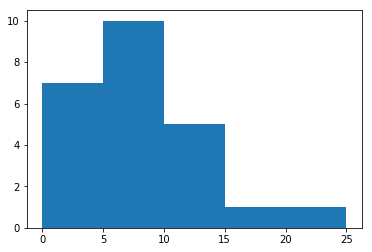

```python
bins =[ 0, 5, 10, 15, 20, 25]
plt.hist(time_different, bins)
plt.show()
```

```python
bins = [0,5,10,15,20,25]
```

```python
time_different_rate = pd.cut(time_different,bins)
print(time_different_rate)
```

```
0      (5, 10]
1       (0, 5]
2     (10, 15]
3      (5, 10]
4      (5, 10]
5      (5, 10]
6      (5, 10]
7      (5, 10]
8     (10, 15]
9     (10, 15]
10      (0, 5]
11      (0, 5]
12      (0, 5]
13      (0, 5]
14    (15, 20]
15    (10, 15]
16     (5, 10]
17     (5, 10]
18     (5, 10]
19    (20, 25]
20    (10, 15]
21      (0, 5]
22      (0, 5]
23     (5, 10]
Name: Time different, dtype: category
Categories (5, interval[int64]): [(0, 5] < (5, 10] < (10, 15] < (15, 20] < (20, 25]]
```

```python
count = pd.value_counts(time_different_rate)
print(count)
```

```
(5, 10]     10
(0, 5]       7
(10, 15]     5
(20, 25]     1
(15, 20]     1
Name: Time different, dtype: int64
```

```python
freqency = print(count,100*count/24)
```

```
(5, 10]     10
(0, 5]       7
(10, 15]     5
(20, 25]     1
(15, 20]     1
Name: Time different, dtype: int64 (5, 10]     41.666667
(0, 5]      29.166667
(10, 15]    20.833333
(20, 25]     4.166667
(15, 20]     4.166667
Name: Time different, dtype: float64
```

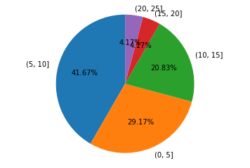

```python
labels = ['(5, 10] ','(0, 5] ','(10, 15] ','(15, 20] ','(20, 25]']
sizes = [10,7,5,1,1]
patches,text1,text2 = plt.pie(sizes,
                      labels=labels,
                      autopct = '%3.2f%%',
                      shadow = False,
                      startangle =90,
                      pctdistance = 0.6)
plt.axis('equal')
plt.show()
```

--同一参与者，不一致情况下条件比一致情况下，说出准确墨色名称的平均时间差异集中在5-10秒，且占比达41.67%。--

(5) 现在，执行统计测试并报告你的结果。你的置信水平和关键统计值是多少？你是否成功拒绝零假设？对试验任务得出一个结论。结果是否与你的期望一致？

```python
# 在这里执行统计检验
```

借鉴：推进统计学入门：“键盘”练习

1）T-critical

双尾检验，第一类发生错误的概率α=0.05， df=24-1=23，查t表格：https://s3.amazonaws.com/udacity-hosted-downloads/t-table.jpg T-critical：2.069

2）T-statistics

A1:在一致文字条件下，参与者说出准确墨色名称时间的均值 A2:在不一致文字条件下，参与者说出准确墨色名称时间的均值 A2-A1 = 22.016-14.051 = 7.965 Time-different的标准差 = 4.865 样本量 = 24

T-statistics=（22.016-14.051）／（4.865／√24）= 8.021

4）作出决策

T-statistics位于临界区域，且p<.0005，说明结果具有统计显著性.零假设成立概率很小，Ho:颜色词与墨色是否一致对说出正确颜色所用的时间没有影响.成立的概率很小 说明对立假设成立的概率较大，即颜色与文字不一致的条件，会显著影响参与者说出准确颜色的时间。

Reference：https://cn.udacity.com/course/intro-to-inferential-statistics--ud201